# Linear Algebra

Part I: Vectors and Matrices

## Why study Linear Algebra & Linear System?

### It is the magic recipe behind everything computational

- It is part of your everyday life!
  - Search Algorithms
  - Voice Assistants (Siri/Alexa)
  - Image & Audio Editing Software
  - ChatGPT & All other Deep Neural Networks

## Image Editing using Linear Algebra

```julia
using Images, ImageIO, ImageMagick
utd = joinpath(pwd(),"utd.jpeg")
utdimg = load(utd)
utdimg
```

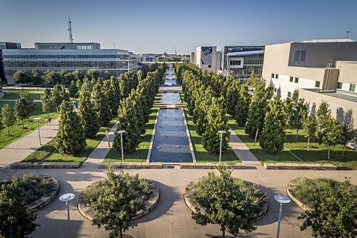

## Image Editing using Linear Algebra

```julia
Float64.(Gray.(utdimg))
```

```
334×500 Matrix{Float64}:
 0.490196   0.490196   0.490196   …  0.443137    0.443137   0.443137
 0.490196   0.490196   0.494118      0.447059    0.447059   0.447059
 0.494118   0.494118   0.494118      0.447059    0.447059   0.447059
 0.498039   0.498039   0.498039      0.45098     0.45098    0.45098
 0.501961   0.501961   0.501961      0.454902    0.454902   0.454902
 0.505882   0.505882   0.505882   …  0.458824    0.458824   0.458824
 0.509804   0.509804   0.509804      0.458824    0.458824   0.458824
 0.509804   0.509804   0.513725      0.462745    0.462745   0.462745
 0.513725   0.513725   0.513725      0.462745    0.462745   0.462745
 0.517647   0.517647   0.517647      0.462745    0.462745   0.462745
 0.521569   0.521569   0.517647   …  0.466667    0.466667   0.466667
 0.52549    0.52549    0.521569      0.466667    0.466667   0.466667
 0.529412   0.529412   0.52549       0.470588    0.470588   0.470588
 ⋮                                ⋱
 0.054902   0.0117647  0.0627451     0.423529    0.54902    0.243137
 0.152941   0.0666667  0.0705882     0.466667    0.52549    0.478431
 0.360784   0.196078   0.101961      0.141176    0.152941   0.203922
 0.341176   0.164706   0.0745098  …  0.0235294   0.152941   0.27451
 0.176471   0.0509804  0.027451      0.00392157  0.0745098  0.164706
 0.133333   0.0313725  0.0313725     0.0627451   0.0235294  0.0941176
 0.0588235  0.0862745  0.0156863     0.113725    0.0745098  0.0352941
 0.423529   0.388235   0.0627451     0.184314    0.105882   0.00392157
 0.333333   0.184314   0.0666667  …  0.243137    0.321569   0.105882
 0.298039   0.34902    0.235294      0.164706    0.423529   0.541176
 0.364706   0.235294   0.403922      0.180392    0.478431   0.321569
 0.196078   0.27451    0.258824      0.141176    0.521569   0.470588
```

## Image Editing using Linear Algebra

```julia
Gray.(utdimg)
```

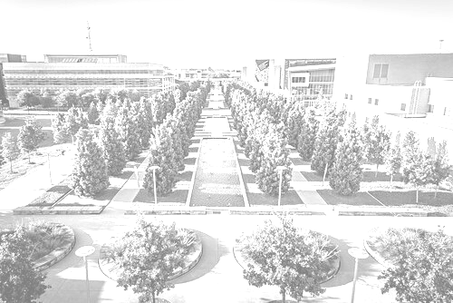

```julia
Gray.(utdimg) .+ 0.5
```

## Image Editing using Linear Algebra

```julia
Gray.(utdimg)
```

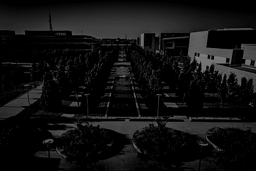

```julia
Gray.(utdimg) .- 0.5
```

## Image Editing using Linear Algebra

```julia
Gray.(utdimg)
```

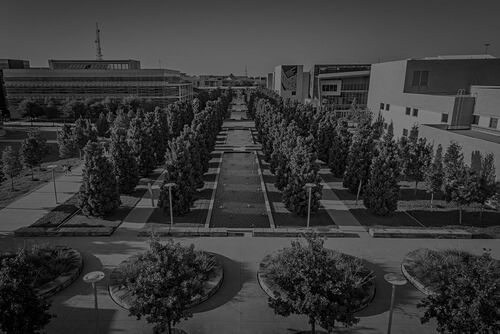

```julia
Gray.(utdimg) .* 0.5
```

## Image Editing using Linear Algebra

```julia
Gray.(utdimg)
```

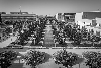

```julia
Gray.(utdimg)[1:5:end,1:5:end]
```

## Building Blocks of Linear Algebra

- Scalars, *c*
  - denoted by italics lowercase character
  - 0D Array

```julia
c = 2
```

```
2
```

- Vectors, $\mathbf{x}= [ x_1, x_2, x_3]$
  - denoted by boldface lowercase character
    - elements of a vector are denoted by lower case characters with subscripts
    - subscripts denote the position of the elements in the vector
  - 1D Array

```julia
# Column Vector
x = [1,2,3]
```

```
3-element Vector{Int64}:
 1
 2
 3
```

```julia
# Row Vector
x = [1 2 3]
```

```
1×3 Matrix{Int64}:
 1  2  3
```

## Building Blocks of Linear Algebra

- Matrices,
  $$\mathbf{A} = \begin{bmatrix}
  a_{11} & a_{12} & c_{13} \\
  a_{21} & a_{22} & a_{23}\\
  \end{bmatrix}$$
  - denoted by uppercase boldface character
    - elements of a matrix are denoted by lowercase character with subscripts
    - subscript denotes the row number and column number of the element
  - 2D Array

```julia
A = [21 12 99;
    11 43 51]
```

```
2×3 Matrix{Int64}:
 21  12  99
 11  43  51
```

- Tensors,
  - N dimensional Array, where $N > 2$

# Vectors

## Vectors are points in space

[figure not shown]

## Vectors are points in space

[figure not shown]

## Scalar Vector Multiplication

$\mathbf{x} = [4,7]$

[figure not shown]

$\mathbf{x} \times 0.2 = [4*0.2, 7*0.2] = [0.8, 1.4]$

[figure not shown]

## Scalar Vector Multiplication

$\mathbf{x} = [4,7]$

[figure not shown]

$\mathbf{x} \times -1 = [4* -1, 7* -1] = [-4, -7]$

[figure not shown]

## Vector Addition

$\mathbf{x} = [1,2]$

[figure not shown]

$\mathbf{y} = [3,1]$

[figure not shown]

## Vector Addition

[figure not shown]

- $\mathbf{x} = [1,2]$
- $\mathbf{y} = [3,1]$

## Vector Addition

[figure not shown]

- $\mathbf{x} = [1,2]$
- $\mathbf{y} = [3,1]$
- $\mathbf{x} + \mathbf{y} = \\ [1,2] + [3,1] = \\ [1+3, 2+1] = \\ [4,3]$
- In Julia:

```julia
x =[1,2]
y = [3,1]
x+y
```

```
2-element Vector{Int64}:
 4
 3
```

## Vector Multiplication

There are several ways to multiply two vectors:

- Dot Product (Inner Product), $\qquad \mathbf{a} \cdot \mathbf{b}$
- Outer Product $\qquad \qquad \quad \mathbf{a} \otimes \mathbf{b}$
- Cross Product $\quad \quad \quad \qquad \mathbf{a} \times \mathbf{b}$
- Hadamard Product $\quad \quad \quad \mathbf{a} \odot \mathbf{b}$
- Kronecker Product $\quad \quad \quad \mathbf{a} \otimes \mathbf{b}$

*Note: These are not the same! Each method gives you a different output.*

## Vector Dot Product

$$\mathbf{a} \cdot \mathbf{b} = \begin{bmatrix} a_{1} \\ \vdots \\ a_{n} \end{bmatrix}
\boldsymbol{\bullet}
\begin{bmatrix} b_{1} \\ \vdots \\ b_{n} \end{bmatrix}
= \sum_{i=1}^{n} a_i b_i$$

## Vector Dot Product

Consider two vectors, $\mathbf{v} = \begin{bmatrix} 3 \\ -1 \\ 2 \end{bmatrix}$, $\mathbf{w} = \begin{bmatrix} 1 \\ 2 \\ 1 \end{bmatrix}$

$$\mathbf{v} \cdot \mathbf{w} = (3 \times 1) + (-1 \times 2) + (2 \times 1) \\
= 3$$

```julia
using LinearAlgebra
v = [3 -1 2]
w = [1 2 1]
dot(v,w)
```

```
3
```

Alternatively,

```julia
v * w'
```

```
1×1 Matrix{Int64}:
 3
```

## Vector Magnitude

- Squareroot of the inner product of a vector with itself gives the magnitude of that vector

[figure not shown]

## Distance between vectors

##### L1 Norm / Manhattan Distance

[figure not shown]

- $|\mathbf{u} -\mathbf{v}|_1 = \\ |3-1| + |1-2| = \\ |2| + |-1| \\ = 3$

```julia
using LinearAlgebra
u = [1,2]
v = [3,1]
norm(u-v,1)
```

```
3.0
```

## Distance between vectors

##### L2 Norm / Euclidean Distance

[figure not shown]

- $|\mathbf{u} -\mathbf{v}|_2 = \\ \sqrt{(3-1)^2 + (1-2)^2} = \\ \sqrt{(2)^2 + (-1)^2} =\\ \sqrt{4+1} = \sqrt{5} = 2.2361$

```julia
using LinearAlgebra
u = [1,2]
v = [3,1]
norm(u-v,2)
```

```
2.23606797749979
```

## Distance between vectors

##### Angular Separation

[figure not shown]

- $$\cos \theta = \frac{\mathbf{u} \cdot \mathbf{v}}{||\mathbf{u}|| ||\mathbf{v}||} =$$
  $\frac{(1 \times 3) + (2 \times 1)}{\sqrt{(1)^1+(2)^2} \times \sqrt{(3)^2+(1)^2}} = \frac{1}{\sqrt{2}}$
- $\theta = \cos^{-1} (\frac{1}{\sqrt{2}}) = \\ 45^{\circ}$

```julia
using LinearAlgebra
u = [1,2]
v = [3,1]
unorm = norm(u,2)
vnorm = norm(v,2)
acosd(dot(u,v) / (unorm*vnorm))
```

```
45.00000000000001
```

## Distance between vectors

##### Angular Separation is a similarity measure

[figure not shown]

```julia
using LinearAlgebra
u = [1,2]
v = [1.5,3]
unorm = norm(u,2)
vnorm = norm(v,2)
acosd(dot(u,v) / (unorm*vnorm))
```

```
8.537736462515939e-7
```

## Linear Neuron Model

[figure not shown]

- What is the output of this neuron model?

# Matrices

## Matrix Operations

#### Addition

```julia
M = [2 6;8 4]
```

```
2×2 Matrix{Int64}:
 2  6
 8  4
```

```julia
N = [1 0;-1 3]
```

```
2×2 Matrix{Int64}:
  1  0
 -1  3
```

```julia
M + N
```

```
2×2 Matrix{Int64}:
 3  6
 7  7
```

#### Multiplication by Scalar

```julia
3 * M
```

```
2×2 Matrix{Int64}:
  6  18
 24  12
```

#### Matrix Transpose

```julia
transpose(M)
```

```
2×2 transpose(::Matrix{Int64}) with eltype Int64:
 2  8
 6  4
```

## Matrix-Vector Multiplication

##### As Linear Transformation

[figure not shown]

- $\mathbf{u} = \begin{bmatrix}4 \\1 \end{bmatrix}$
- Multiply $\mathbf{u}$ by $\mathbf{A} = \begin{bmatrix}1 & -3 \\1 & -1 \end{bmatrix}$

## Matrix-Vector Multiplication

##### As Linear Transformation

[figure not shown]

## Matrix-Vector Multiplication

##### As Linear Transformation

$\begin{bmatrix}1 & -3 \\1 & -1 \end{bmatrix} \begin{bmatrix} 4 \\ 1 \end{bmatrix} =$
$$4 \begin{bmatrix} 1 \\ 1 \end{bmatrix} + 1 \begin{bmatrix} -3 \\ - 1\end{bmatrix} =$$

$$\begin{bmatrix} 1 \\ 3 \end{bmatrix}$$

[figure not shown]

## Matrix-Vector Multiplication

##### As Linear Transformation (Coordinate Transformation)

[figure not shown]

- blue represents the transformed coordinates

## Matrix-Vector Multiplication

What is the value of $\mathbf{u}$?
$$\mathbf{u} = \begin{bmatrix} 3 & 4 & 5 \\ 1 & 0 & 1 \end{bmatrix}
\begin{bmatrix} 1 \\ 0 \\ 2\end{bmatrix}$$

## Matrix-Vector Multiplication

What is the value of $\mathbf{u}$?
$$\mathbf{u} = \begin{bmatrix} 3 & 4 & 5 \\ 1 & 0 & 1 \end{bmatrix}
\begin{bmatrix} 1 \\ 0 \\ 2\end{bmatrix}$$

$= 1 \begin{bmatrix} 3 \\ 1 \end{bmatrix} + 0 \begin{bmatrix} 4 \\ 0 \end{bmatrix} + 2 \begin{bmatrix} 5 \\ 1 \end{bmatrix}$

$= \begin{bmatrix} 13 \\ 3 \end{bmatrix}$

```julia
w = [3 4 5; 1 0 1]
v= [1,0,2]
w*v
```

```
2-element Vector{Int64}:
 13
  3
```

## Connection Weight Matrix

[figure not shown]

$$\begin{bmatrix}
w_{11} & w_{12} & w_{13} & w_{14} \\
w_{21} & w_{22} & w_{23} & w_{24}\\
w_{31} & w_{32} & w_{33} & w_{34}\\
\end{bmatrix}$$

$$\mathbf{r} = \mathbf{W} \mathbf{x}$$

## Connection Weight Matrix

[figure not shown]

$$\begin{bmatrix}
w_{11} & w_{12} & w_{13} & 0 \\
0 & 0 & 0 & w_{24}\\
0 & 0 & w_{33} & w_{34}\\
\end{bmatrix}$$

$$\mathbf{r} = \mathbf{W} \mathbf{x}$$

## Connection Weight Matrix

[figure not shown]

$$\begin{bmatrix}
w_{11} & w_{12} & w_{13} & 0 \\
0 & 0 & 0 & w_{24}\\
0 & 0 & w_{33} & w_{34}\\
\end{bmatrix}$$

$$\mathbf{r} = \mathbf{W} \mathbf{x}$$

$$\mathbf{y} = \mathbf{H} \mathbf{r}$$

## Matrix-Matrix Multiplication

$\begin{bmatrix} 1 & 2 \\ 3 & 1 \\ 1 & -1 \\ \end{bmatrix} \begin{bmatrix} 3 & 1 \\ 1 & 2 \\ \end{bmatrix} =$

$$\begin{bmatrix} \begin{bmatrix} 1 & 2 \end{bmatrix} \cdot \begin{bmatrix} 3 \\ 1\end{bmatrix} &
\begin{bmatrix} 1 & 2 \end{bmatrix} \cdot \begin{bmatrix} 1 \\ 2\end{bmatrix} \\
\begin{bmatrix} 3 & 1 \end{bmatrix} \cdot \begin{bmatrix} 3 \\ 1\end{bmatrix} &
\begin{bmatrix} 3 & 1 \end{bmatrix} \cdot \begin{bmatrix} 1 \\ 2\end{bmatrix} \\
\begin{bmatrix} 1 & -1 \end{bmatrix} \cdot \begin{bmatrix} 3 \\ 1\end{bmatrix} &
\begin{bmatrix} 1 & -1 \end{bmatrix} \cdot \begin{bmatrix} 1 \\ 2\end{bmatrix} \\
\end{bmatrix} =$$

$$\begin{bmatrix} 5 & 5 \\ 10 & 5 \\ 2 & - 1 \end{bmatrix}$$

```julia
A = [1 2; 3 1;1 -1]
B = [3 1; 1 2]
A * B
```

```
3×2 Matrix{Int64}:
  5   5
 10   5
  2  -1
```